[figure not shown]

## Goats 2015

**Wed Apr 13 12:31:26 2022**

### 1 Overview

The raster GIS layer on Goats (2015) described in this document are part of the **Gridded Livestock of the World database (GLW v4)**.

The GLW database was developped to meet three objectives:

1. Collect, harmonize and disseminate sub-national global data on livestock distribution;
2. Predict livestock numbers in areas with missing informations on livestock census counts;
3. Provide an statistically-informed estimate of how livestock may distribute within census unit through downscaling algoritms.

Two main methods have been described in the litterature for distributing census data at the pixel level. The **areal-weighted (AW)** method simply considers that all pixels of the census area are equally suitable, and assign them an equal weight. It simply corresponds to the density of animals per km<sup>2</sup> in the census unit multiplied by the pixel area. The **dasymetric method (DA)** assigns different weights to different pixels based on high resolution environmental predictor variables and Random Forest models, and the animal census counts are distributed according to these weights.

The **AW** and **DA** GLW global distribution data fit different purposes. The **DA** GLW models provide an estimate of how livestock species may be distributed *within* census areas. However, spatial predictors (e.g. human population density, vegetation indices, topography, etc.) that are used to derived the downscaling weights may introduce some uncontrolled counfonding effects for users willing to quantify the effect of livestock alongside these spatial predictors on an outcome. Similarly, the **DA** models may introduce circularity for users willing to use livestock data to study their impact on some these spatial factors, such as land-use, for example. The **AW** GLW models are free of any influence of spatial predictor variables, but produces more unrealistic distribution patterns, especially in large census areas containing a wide range of different land-use and farming conditions.

This report presents snapshots and links to high resolution maps of the different data layers available with the GLW v4 data package for Goats (2015). Three GIS layers are provided, as geotiff, with an global extent with the projection CRS “+proj=longlat”. The suffix “10k” or “1k” corresponds to a spatial resolution of 0.083333 or 0.0083333 decimal degrees, respectively:

1. **DA GLW model (5_Gt_2015_Da_10k.tif)**: This geotif layer contains the DA animal numbers per pixel, with weight estimated by the Random Forest model. Note that the totals number of animals per census polygon of the DA and AW GLW models should be identical.
2. **AW GLW model (6_Gt_2015_Aw_10k.tif)**: This geotif layer contains the AW animal numbers per pixel in polygons where data where available in the subnational census, and AW predictions from the model in census area where the information was missing.
3. **AW GLW prediction status (7_Gt_2015_Ps_10k.tif)**: This geotif layer contains a value of 0 in pixels where the AW animal number is from a census, and value of 1 if the value was predicted by the GLW model.

### 2 Snapshots

Note that the snapshot below were produced in the equal-area pseudocylindrical Eckert IV projection for a proper representation of densities. The standard lat/long visualisation of global raster data tend to visually over-represent animal densities in pixels located in northern latitudes as they cover a much lower surface on earth than those close to the equator. Altough the data files are distributed in lat/long, we recommend the use of an equal-area projection for displaying our livestock density data.

#### 2.1 Dasymetric GLW model

A high-resolution version can be visualised here.

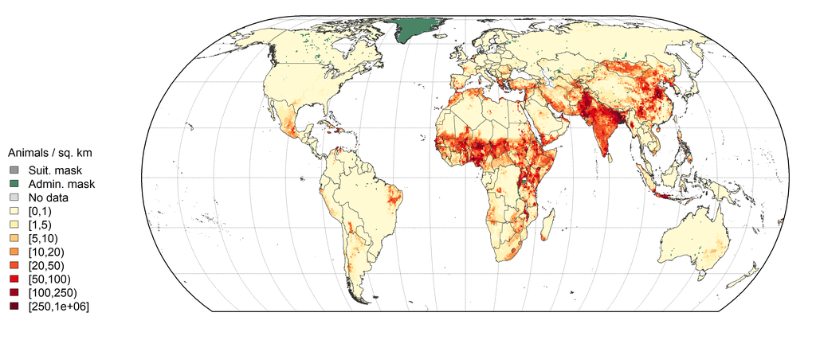

#### 2.2 Areal-weighted GLW model

A high-resolution version can be visualised here.

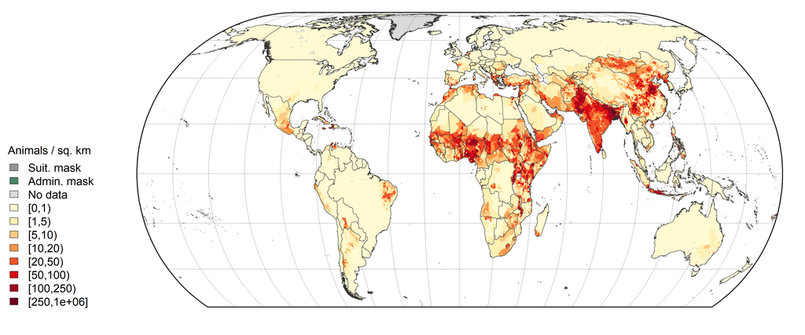

#### 2.3 Areas predicted in the AW model

A high-resolution version can be visualised here.

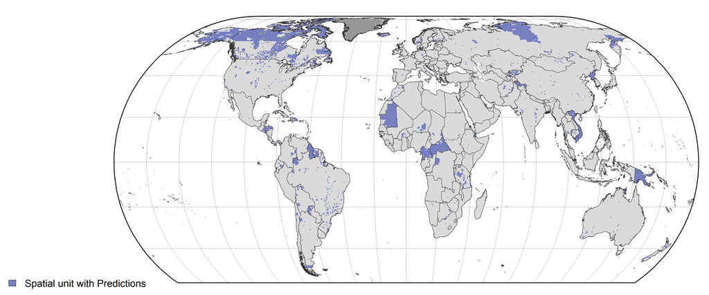

### 3 Description of sub-national census data

#### 3.1 Average Spatial Resolution (ASR)

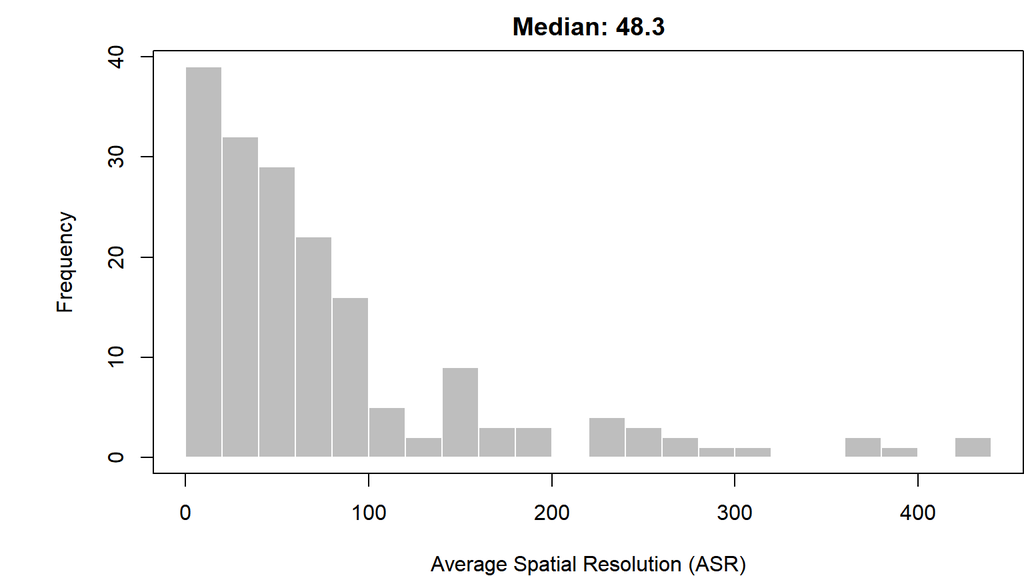

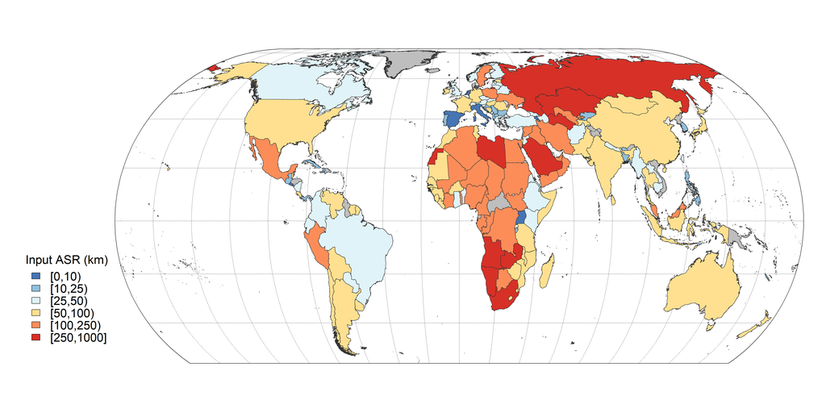

#### 3.2 Year of the sub-national input data

The following histogram and maps show the year of sub-national census data used for the GLW models.

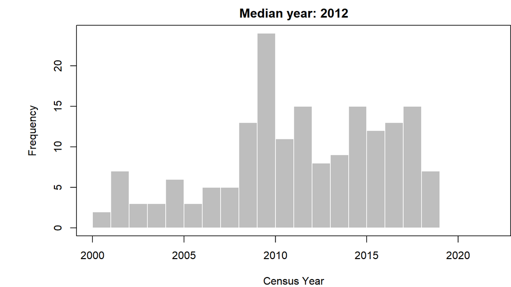

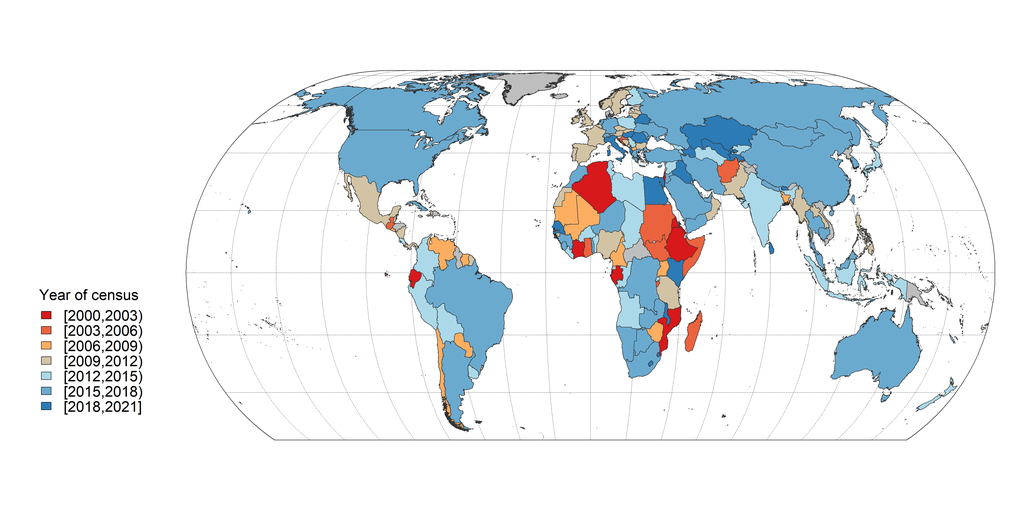

### 4 Goodness of fit of polygon-level predictions

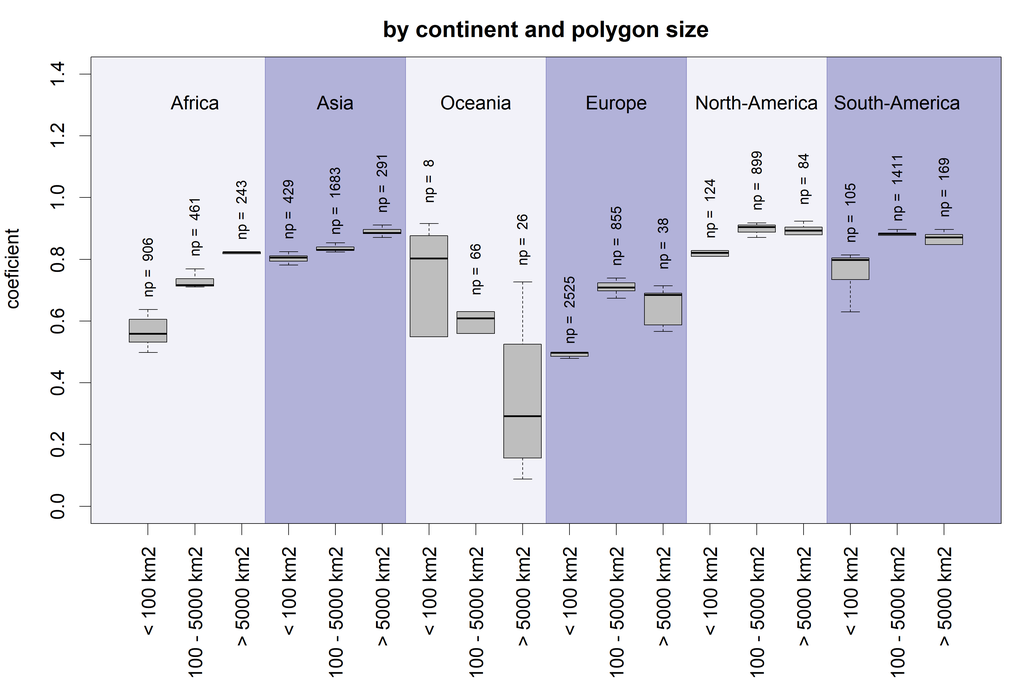

### 5. Citations

The GLW database was originally described by Wint & Robinson (GLW v1, 2007) and used the DA method with weights quantified through stratified multiple regressions. The modelling procedure was automated and standardized for GLW v2 (Robinson *et al.* 2014) and the methodology used to derived the weights was recently improved by replacing stratified linear regression by Random Forest for producing GLW v3.0 (Nicolas *et al.* 2016). This dataset is described in full in Gilbert *et al.* (2018).

- Gilbert M., G. Nicolas, G. Cinardi, G.R.W. Wint, S. Vanwambeke, T.P. Robinson (2018) Global Distribution Data for Cattle, Buffaloes, Horses, Sheep, Goats, Pigs, Chickens and Ducks in 2010. *Sci. Data*. 5:180227 https://doi.org/10.1038/sdata.2018.227
- Nicolas G., TP Robinson, G.R.W. Wint, G. Conchedda, G. Cinardi, M. Gilbert (2016) Using random forest to improve the downscaling of global livestock census data. *Plos ONE* 11(3): e0150424. http://dx.doi.org/10.1371/journal.pone.0150424
- Robinson, T., W. Wint, T, G. Conchedda, T. P. Van Boeckel, V. Ercoli, E. Palamara, G. Cinardi, L. D’Aietti, & M. Gilbert (2014) Mapping the Global Distribution of Livestock. *PLoS ONE* 9(5): e96084. http://dx.doi.org/10.1371/journal.pone.0096084
- Wint, W., and T. Robinson (2007) *Gridded Livestock of the World*. Food and Agricultural Organisation, Rome, Italy.http://www.fao.org/docrep/010/a1259e/a1259e00.htm

### 6. Country census data references

Table continues below

|  | Country | ASR | Year | Census | FAOSTAT | Source |
| --- | --- | --- | --- | --- | --- | --- |
| **AFG** | Afghanistan | 43.5 | 2003 | 7,216,121 | 7,723,000 | Ministry of Agriculture, Irrigation and Livestock of Afghanistan |
| **ALB** | Albania | 21.6 | 2018 | 897,445 | 932,000 | Institute of Statistics, Albania |
| **DZA** | Algeria | 220.1 | 2002 | 2,875,820 | 5,013,950 | Direction des Services Vétérinaires - Ministère de l’Agriculture et du Développement rural, 2003 |
| **AND** | Andorra | 8.2 | 2012 | 371 | NA | Departament d’Estadística, Govern d’Andorra |
| **AGO** | Angola | 264.0 | 2013 | 4,164,696 | 4,385,978 | CountrySTAT - Food and agriculture data network |
| **ATG** | Antigua and Barbuda | NA | NA | NA | 26,996 | -9999 |
| **ARG** | Argentina | 74.4 | 2016 | 4,712,173 | 4,720,674 | Servicio Nacional de Sanidad y Calidad Agroalimentaria, Argentina |
| **ARM** | Armenia | 5.8 | 2014 | 35,389 | 31,891 | National Statistical Service of the Republic of Armenia |
| **AUS** | Australia | 84.2 | 2016 | 411,836 | 3,600,000 | Australian Bureau of Statistics |
| **AUT** | Austria | 29.2 | 2010 | 80,894 | 70,705 | Statistics Austria |
| **AZE** | Azerbaijan | 35.0 | 2018 | 622,426 | 651,479 | The State Statistical Committee of the Republic of Azerbaijan |
| **BHS** | Bahamas | NA | NA | NA | 15,013 | -9999 |
| **BHR** | Bahrain | NA | NA | NA | 19,151 | -9999 |
| **BGD** | Bangladesh | 17.4 | 2008 | 16,191,517 | 56,000,000 | Bangladesh Bureau of Statistics |
| **BRB** | Barbados | NA | NA | NA | 5,393 | -9999 |
| **BLR** | Belarus | 42.0 | 2018 | 64,035 | 68,500 | National Statistical Committee of the Republic of Belarus |
| **BEL** | Belgium | 26.7 | 2010 | 31,560 | 43,602 | Directorate-General Statistics Belgium |
| **BLZ** | Belize | 61.0 | 2011 | 823 | 183 | World Organisation for Animal Health - OIE |
| **BEN** | Benin | 38.9 | 2013 | 860,000 | 1,795,000 | CountrySTAT - Food and agriculture data network |
| **BTN** | Bhutan | 13.8 | 2018 | 43,735 | 41,983 | Ministry of Agriculture and Forest, Royal Government of Bhutan |
| **BOL** | Bolivia | 59.4 | 2013 | 3,737,024 | 2,181,219 | Instituto Nacional de Estadística, Bolivia |
| **BIH** | Bosnia and Herzegovina | 68.2 | 2009 | 70,604 | 72,823 | Federal office of Statistics, Federation of Bosnia and Herzegovina |
| **BWA** | Botswana | 171.0 | 2015 | 1,183,612 | 1,205,238 | Central Statistics Office Republic of Botswana |
| **BRA** | Brazil | 41.2 | 2017 | 8,213,074 | 9,620,877 | Istituto Brasileiro de Geografia e Estatistica |
| **BRN** | Brunei Darussalam | NA | NA | NA | 7,283 | -9999 |
| **BGR** | Bulgaria | 20.7 | 2010 | 388,291 | 292,644 | Ministry of Agriculture and Forestry - Agrostatistics Directorate, Bulgaria |
| **BFA** | Burkina Faso | 80.8 | 2014 | 11,308,432 | 14,308,172 | Conseil National de la Satistique, Burkina Faso |
| **BDI** | Burundi | 15.2 | 2005 | 1,126,579 | 2,357,387 | Direction Provinciale de l’Agriculture et de l’Elevage, Burundi (DPEA) |
| **KHM** | Cambodia | 33.5 | 2017 | 17,527 | NA | General Directorate of Animal Health and Production - Ministry of Agriculture, Forestry and Fisheries, Cambodia |
| **CMR** | Cameroon | 235.2 | 2006 | 1,134,772 | 5,020,334 | CountrySTAT - Food and agriculture data network |

[output cut: 170 more lines]

|  | Reference |
| --- | --- |
| **AFG** | Afghanistan – National Livestock Census 2002-2003 –- Final Report (http://reliefweb.int/sites/reliefweb.int/files/resources/58C374339FC582F149256DF30009D60F-fao-afg-4dec.pdf) |
| **ALB** | Number of livestock by Municipality, Livestock, Type and Year 2018 |
| **DZA** | Direction des Services Vétérinaires - Ministère de l’Agriculture et du Développement rural, 2003 |
| **AND** | Cabana Ramadera per Tipus i Parròquia, 2011-2012 (http://www.estadistica.ad/serveiestudis/web/index.asp) |
| **AGO** | CountrySTAT Angola: Número de animais vivos by Ano, Especie, Nivel administrativo. (http://countrystat.org/home.aspx?c=AGO&ta=007SPD035&tr=21) - last access 10/2014 |
| **ATG** | -9999 |
| **ARG** | Existencias animal por Provincia/Departamento 2008-2017 (personal communication) |
| **ARM** | Agricultural Census 2014 of the Republic of Armenia (https://www.armstat.am/en/?nid=124) |
| **AUS** | Agricultural Census 2015-16 (https://www.abs.gov.au/AUSSTATS/abs@.nsf/DetailsPage/7121.02015-16?OpenDocument) |
| **AUT** | Agricultural Census 2010 (http://statcube.at/superwebguest/login.do?guest=guest&db=deas1002) |
| **AZE** | The Agriculture of Azerbaijan 2019 - Statistical Yearbook (https://www.stat.gov.az/menu/6/statistical_yearbooks/?lang=en) |
| **BHS** | -9999 |
| **BHR** | -9999 |
| **BGD** | Agriculture Census Report 2008 - online data http://www.bbs.gov.bd/home.aspx |
| **BRB** | -9999 |
| **BLR** | Interactive information and analytical system for dissemination of official statistical information (http://dataportal.belstat.gov.by/Indicators/Search) |
| **BEL** | Farm structure survey (FSS) 2010 (http://ec.europa.eu/eurostat/statistics-explained/index.php/Agricultural_census_in_Belgium) |
| **BLZ** | Belize: World Animal Health Information Database (WAHID) - Animal Population 2010-2011 (http://www.oie.int/wahis_2/public/wahid.php/Countryinformation/Animalpopulation) |
| **BEN** | CountryStat Benin: Élevage – Total des effectifs d’animaux vivants 2010-2013 (http://www.countrystat.org/home.aspx?c=BEN&ta=053SPD135&tr=21) - last access 10/2014 |
| **BTN** | Livestock Statistics 2018 (http://www.moaf.gov.bt/download/Statisitcs/#wpfb-cat-2) |
| **BOL** | Censo Nacional Agropecuario 2013 (http://datos.ine.gob.bo/binbol/RpWebEngine.exe/Portal?BASE=CNA2013&lang=ESP) |
| **BIH** | Number of animals from Federalni |
| **BWA** | Botswana Agricultural Census Report 2015 (http://www.statsbots.org.bw/sites/default/files/Botswana%20Agriculture%20Census%20Report%20Final%202015..pdf) |
| **BRA** | Censo Agropecuário 2017 (https://censoagro2017.ibge.gov.br/templates/censo_agro/resultadosagro/index.html) |
| **BRN** | -9999 |
| **BGR** | Agricultural Census 2010 (http://www.mzh.government.bg/MZH/ShortLinks/SelskaPolitika/Agrostatistics/Structure_agricultural_holdings/Results.aspx) |
| **BFA** | Publications des directions régionales de l’INSD - 2014 (http://www.cns.bf/spip.php?id_rubrique=99&page=publication) |
| **BDI** | Monographies des les Communes, 2006 |
| **KHM** | L2/2017 GDAHP’s Report 2017 combined with L2/2011 Cambodia Livestock Census 2011 |
| **CMR** | CountrySTAT - Food and agriculture data network: Cameroon |

[output cut: 170 more lines]